# Tarea 1 Modelos de Supervivencia y Series de Tiempo

## - Una serie de tiempo se puede descomponer en los siguientes componentes.(Seleccione la opción correcta)

1. Tendencia, Estacionariedad y Parte Aleatoria
2. Parte Aditiva y Parte Multiplicativa

## - ¿Cuáles son las razones por las que se sugiere aplicar transformaciones como suavizamiento a través de medias móviles o diferenciación a las series de tiempo?

1. La mayoría de las series de tiempo no son débilmente estacionarias, es decir que no muestran una media ni una varianza constantes a lo largo del tiempo y pueden mostrar tendencias crecientes o bien, decrecientes. Para poder trabajar con este tipo de series de una forma más sencilla y manejable, existen métodos para transformarlas y verlas como realizaciones de una serie de tiempo débilmente estacionaria. Las transformaciones más comunes son el suavizamiento a través de medias móviles o ajustando polinomios a la serie en cuestión, la diferenciación.

## - Un conjunto de 144 medidas del número de pasajeros mensuales en líneas aereas están en el objeto AirPassengers.

### Grafique la serie de tiempo. ¿Que patrón se observa?/

Primero carguemos los datos:

```r
library(ggfortify)
library(tseries)
library(forecast)

data(AirPassengers)
AirP <- AirPassengers
```

Ahora procedamos a graficar nuestros datos, justo como se muestra a continuación:

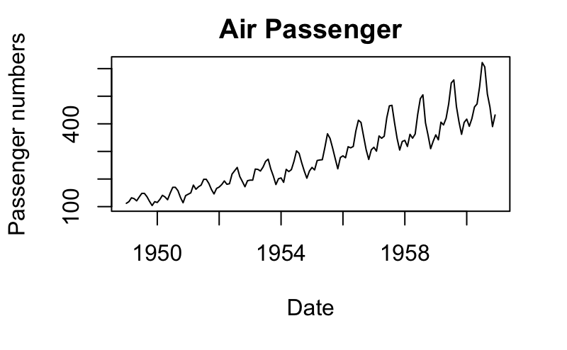

```r
plot(AirP,xlab="Date", ylab = "Passenger numbers",main="Air Passenger")
```

### Grafique la serie de los logaritmos de los datos. ¿Qué cambio observa?

Para este caso haré uso de plot, de este modo optenemos:

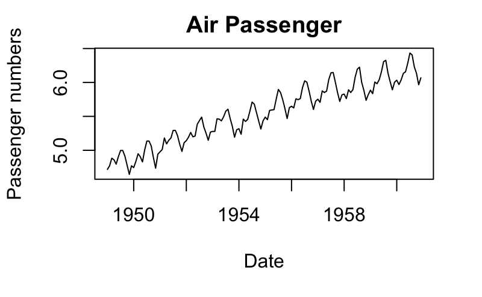

```r
AirPLog = log(AirP)
plot(AirPLog,xlab="Date", ylab = "Passenger numbers",main="Air Passenger")
```

### Grafique la serie de las diferencias de los logaritmos de los datos. ¿El gráfico sugiere que un modelo estacionario podría ser apropiado para las diferencias de los logaritmos? Explique brevemente

Primero veamos que la diferencia de logaritmos de los datos podemos expresarla como:
$$diff(logX)=logX_{t} -
logX_{t-1}$$
de esta forma grafiquemos la serie de las diferencias de los logaritmos de los datos:

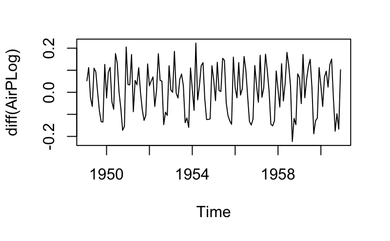

```r
plot(diff(AirPLog))
```

Como se puede apreciar en la gráfica obtenida, ahora obtenemos una serie estacionaria, es decir, se mantiene una varianza constante al igual que la media; por lo cual podemos intuir que en este caso es apropiado para la diferencia de logaritmos.

### Grafique la serie de tiempo. ¿Qué patrón se observa?

Primero carguemos los datos:

```r
data(gold)
goldPrice <- gold
```

Ahora procedamos a graficar nuestros datos, justo como se muestra a continuación:

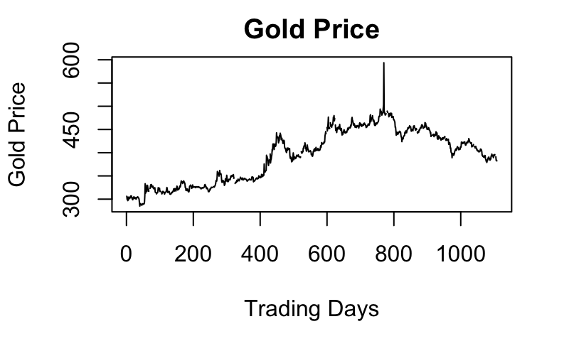

```r
plot(goldPrice,xlab="Trading Days", ylab = "Gold Price",main="Gold Price")
```

Podemos notar en la gráfica anterior que no se tiene una varianza y media no constantes, es decir, no es estacionaria, de igual forma se ve que no tiene tendencia constante.

### Grafique la serie de las diferencias de los logaritmos de los datos. ¿El gráfico sugiere que un modelo estacionario podría ser apropiado para las diferencias de los logaritmos? Explique brevemente.

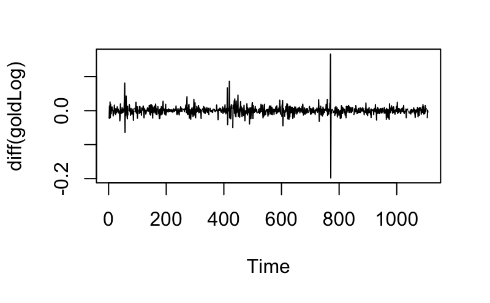

Como se puede apreciar en la gráfica obtenida, ahora obtenemos una serie estacionaria (aproximadamente), es decir, se mantiene una varianza aproximadamente constante al igual que la media; por lo cual podemos intuir que en este caso es apropiado para la diferencia de logaritmos.

### Utilice la función ACF para las diferencias de los logaritmos de los datos. ¿Es evidencia suficiente de que los log-precios del oro siguen un modelo de caminata aleatoria?, ¿por qué?

[figure not shown]